# Codes for Figure1

## Generating figures 1b-d and 1f

#### Set up the environment and load the data

```r
rm(list=ls())
pwd <- getwd()
pwd <- substr(pwd,1,nchar(pwd)-8)
library(pheatmap)
library(grid)
### load expression and meta data of homeostasis and transplantation cell
load(paste0(pwd,"/input/01.QC.Comb.cell.count.tpm.meta.Rdata"))
### load HSC PCA top genes and homeostasis cell clusters
load(paste0(pwd,"/input/02.pc.topGenes.HSC.RData"))
load(paste0(pwd,"/input/02.Homeostasis.Cells_cluster_pc.topGenes.RData"))
```

### Figure 1b

```r
cell.type <- "HSC"
cell.subtype <- c("LT_HSC", "Fraction I", "Fraction III", "ESLAM", "ESLAMSK")
# number of gene sets distinguishing cell type subsets
max(pc.genes[pc.genes$Celltype == cell.type,]$Cluster) # 4
```

```
## [1] 4
```

```r
# number of subsets within HSC cell type
max(pc.cells[pc.cells$Celltype == cell.type,]$Cluster) # 3
```

```
## [1] 3
```

For HSC, genes have 4 clusters and cells have 3 clusters, so we can set the row cut 4 and the column cut 3 for the heatmap

```r
cut.row <- 4
cut.col <- 3
```

plot the heatmap

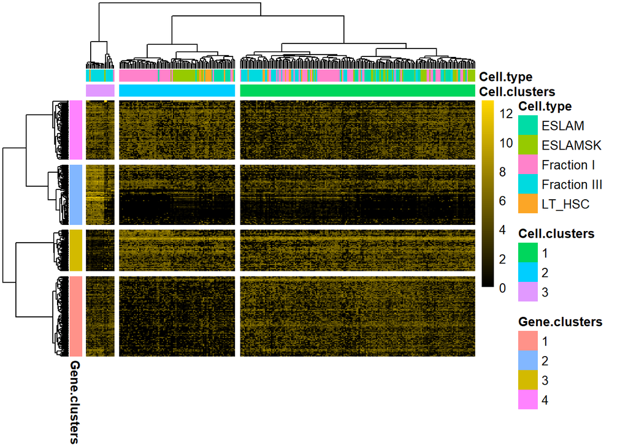

```r
#305 cells of HSCs
input.meta <- comb.data.meta[pc.cells[pc.cells$Celltype == cell.type,]$Cell,]
input.mtx <- comb.data.tpm[pc.topGenes, rownames(input.meta)]
### the following codes are similar to the second part.
input.dist.row <- as.dist(1-cor(t(input.mtx), method = "pearson"))
input.clust.row <- hclust(input.dist.row, method = "ward.D2")
input.dist.col <- as.dist(1-cor(input.mtx, method = "pearson"))
input.clust.col <- hclust(input.dist.col, method = "ward.D2")
col.panel <- colorRampPalette(colors = c("black", "gold"))
input.cutree.row <- cutree(input.clust.row, k = cut.row)
input.cutree.col <- cutree(input.clust.col, k = cut.col)
input.meta$clusters <- input.cutree.col
input.meta <- input.meta[order(input.meta$clusters),]

input.heatmap <- pheatmap(input.mtx, color=col.panel(100), cluster_rows = T,
                          cluster_cols = T, legend = T, show_colnames = F, show_rownames = F,
                          clustering_distance_rows = "correlation", clustering_distance_cols = "correlation",
                          clustering_method = "ward.D2",
                          annotation_col = data.frame("Cell clusters" = factor(input.meta$clusters), "Cell type" = input.meta$phenotype, row.names= row.names(input.meta)),
                          annotation_row = data.frame("Gene clusters" = factor(input.cutree.row), row.names = pc.topGenes),
                          cutree_rows = max(input.cutree.row), cutree_cols = max(input.cutree.col))
```

and we can alse see the expression distribution of the selected genes

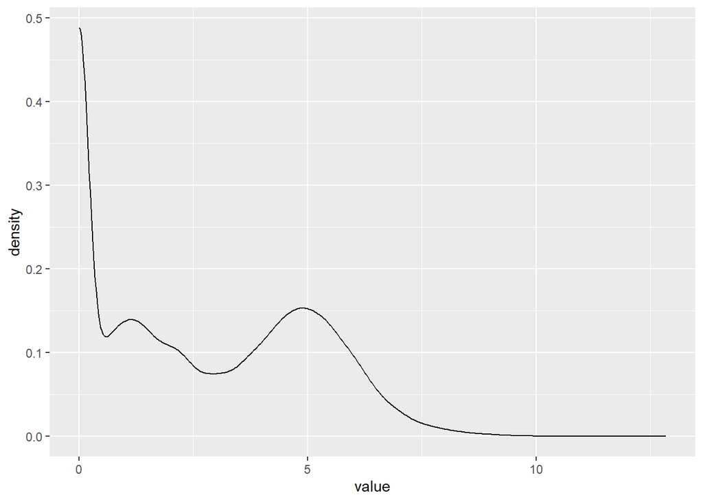

```r
# visualised expression distribution
library(data.table)
library(ggplot2)
ggplot(reshape2::melt(input.mtx),aes(x=value))+geom_line(stat="density",colour="black")
```

We can increase contrast by set genes expression level higher than 8 equally to 8.

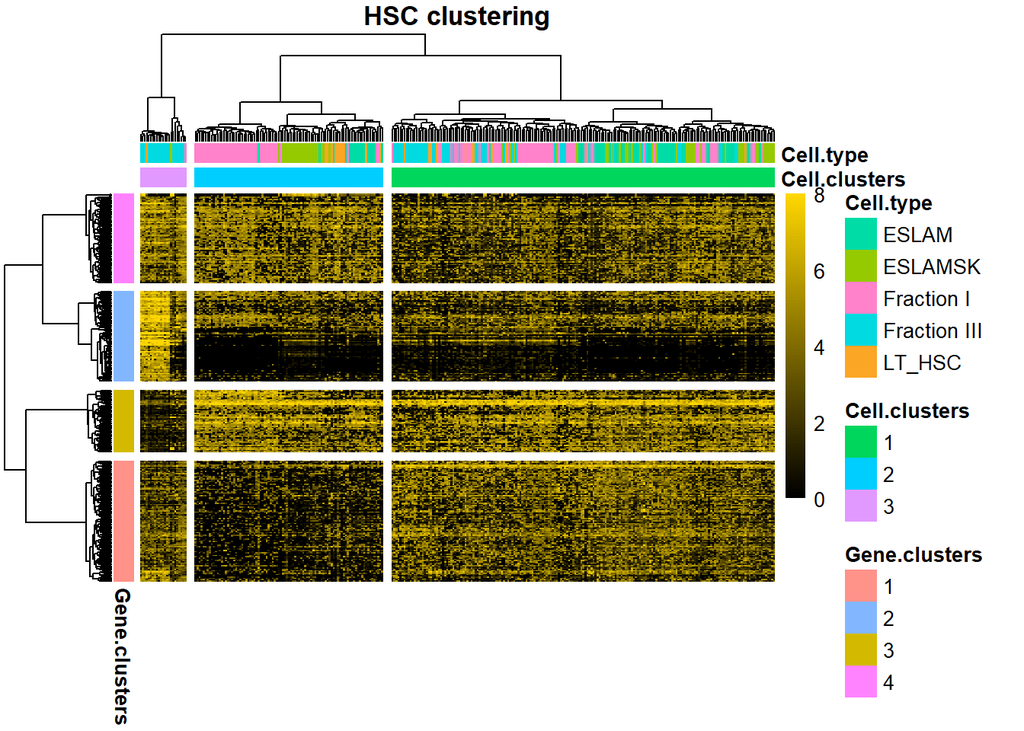

```r
#set genes expression level higher than 8 equally to 8, and visualise clustering
input.mtx[ input.mtx > 8] <- 8
#pdf(paste0(pwd,"/output/Figure.1b.", cell.type, ".clustering.heatmap.pdf"), onefile = F)
pheatmap(input.mtx, color=col.panel(100), cluster_rows = input.heatmap$tree_row,
         cluster_cols = input.heatmap$tree_col, legend = T, show_colnames = F, show_rownames = F,
         annotation_col = data.frame("Cell clusters" = factor(input.meta$clusters), "Cell type" = input.meta$phenotype, row.names= row.names(input.meta)),
         annotation_row = data.frame("Gene clusters" = factor(input.cutree.row), row.names = pc.topGenes),
         cutree_rows = max(input.cutree.row), cutree_cols = max(input.cutree.col),
         main = paste(cell.type, "clustering"))
```

### Figure 1c

UMAP plot showing the three heterogeneous clusters of five iHSC populations: tHSC1 (n = 189), tHSC2 (n = 93) and tHSC3 (n = 23)

Warning: The package version is updated. this paper uses Seurat2 and monocle2 to analysis the data and plot. Here we use Seurat3 and monocle3. So there are some changes in the code, but they do not affect the results.

```r
### note:figure 1c showed slightly different from published one for uwot
### packages had updated and same parameters we had used were missing.
library(Seurat)
library(uwot)
input.umi <- comb.data.counts[,rownames(input.meta)]
raw.obj <- CreateSeuratObject(
    counts = input.umi, min.cells = 3, min.genes = 0,
    meta.data = input.meta, project = "HSC")
raw.obj <- NormalizeData(object = raw.obj, normalization.method = "LogNormalize", scale.factor = 10000)
raw.obj <- ScaleData(raw.obj, display.progress = F)
```

```
## Warning: The following arguments are not used: display.progress
```

```
## Suggested parameter: verbose instead of display.progress
```

```r
raw.obj <- FindVariableFeatures(object = raw.obj, mean.function = ExpMean, dispersion.function = LogVMR, x.low.cutoff = 0.25, x.high.cutoff = 3, y.cutoff = 0.5)
length(x = raw.obj@assays$RNA@var.features)
```

```
## [1] 2000
```

```r
high.var.gene = raw.obj@assays$RNA@var.features[1:1101]
raw.obj <- RunPCA(object = raw.obj,pc.genes =high.var.gene, do.print = TRUE, pcs.print = 1:5, genes.print = 5)
```

[output not shown]

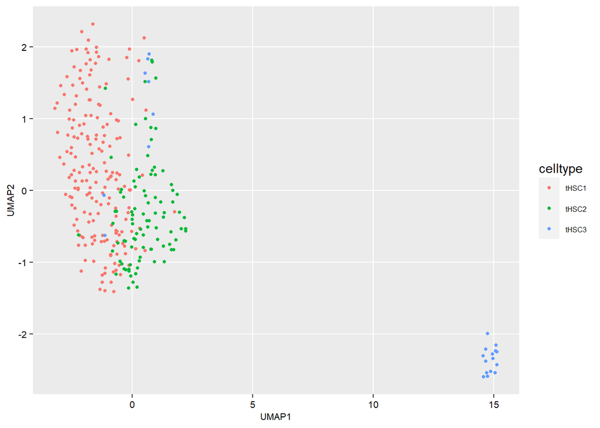

```r
# extract PCA for uwot
data.plot <- as.matrix(raw.obj@reductions$pca@cell.embeddings)
set.seed(123)
umap <- umap(data.plot[,1:11],n_neighbors = 15, n_components = 3, metric = "euclidean",
     n_epochs = NULL, scale = FALSE, init = "random", min_dist=0.5, spread=0.7,
     set_op_mix_ratio = 1,local_connectivity = 1, bandwidth = 1, repulsion_strength = 1,
     target_weight = 0.5)
umap <- as.data.frame(umap)
colnames(umap) <- paste0("UMAP",c(1:3))
rownames(umap) <- rownames(raw.obj@meta.data)
umap <- cbind(umap[,c(1:2)],raw.obj@meta.data)
umap$celltype <- paste0("tHSC",umap$cluster)
theme_imfo <- theme(legend.position="right",legend.spacing.y = unit(0.1, 'cm'),legend.text = element_text(colour="black", size=6),
    axis.text=element_text(size=8,color="black"),axis.text.x=element_text(size=8),axis.title.x = element_text(size = 8),
    axis.text.y = element_text(size = 8,color="black"),axis.title.y = element_text(size = 8),panel.grid.minor = element_blank())
ggplot(data=umap, aes(x=UMAP1, y=UMAP2,colour=celltype)) + geom_point(aes(colour=celltype),alpha=1,size=1) +
     labs(fill="Celltype")+ guides(fill=guide_legend(keywidth=0.1,keyheight=0.1,default.unit="inch")) +
     xlab("UMAP1") + ylab("UMAP2") + theme_imfo
```

**The clustering of 305 HSC cells is not completely separate in the umap plot. Here we use Seurat’s PCA,UMAP,TSNE and PHATE to see the dimensionality reduction effects of these different methods.**

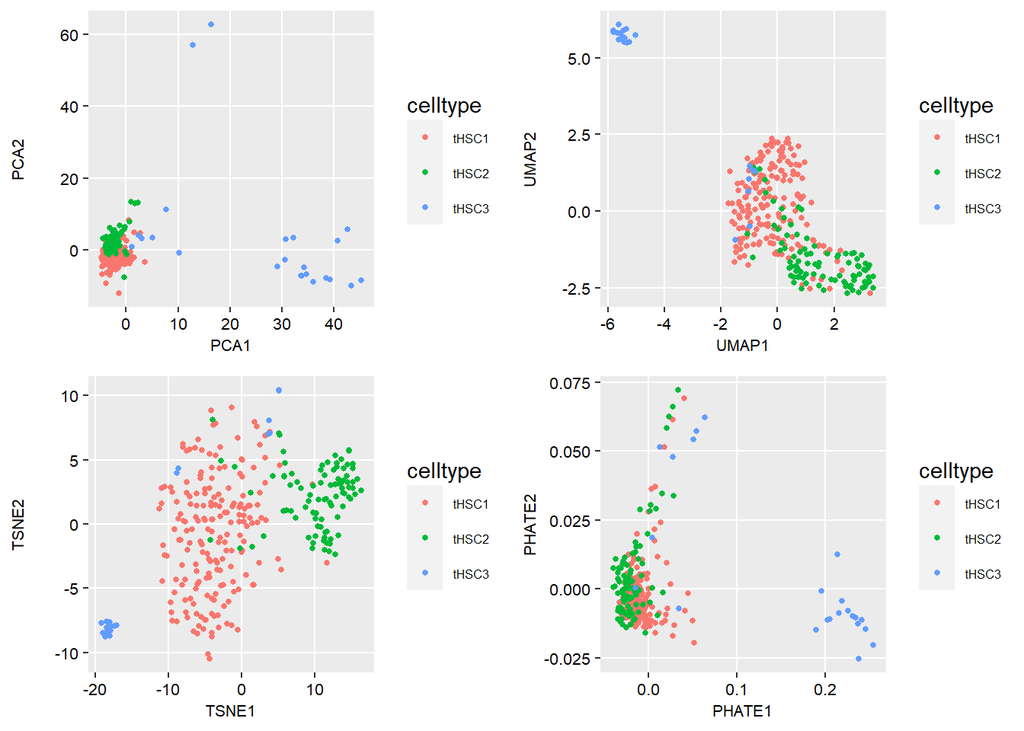

```r
#pca of HSC
pca1to4_seurat <- as.data.frame(raw.obj@reductions$pca@cell.embeddings[,1:4])
colnames(pca1to4_seurat) <- paste("PCA",1:4,sep = "")
rownames(pca1to4_seurat) <- rownames(raw.obj@meta.data)
pca1to4_seurat <- cbind(pca1to4_seurat,raw.obj@meta.data)
pca1to4_seurat$celltype <- paste0("tHSC",pca1to4_seurat$cluster)
theme_imfo <- theme(legend.position="right",legend.spacing.y = unit(0.1, 'cm'),legend.text = element_text(colour="black", size=6),
                    axis.text=element_text(size=8,color="black"),axis.text.x=element_text(size=8),axis.title.x = element_text(size = 8),
                    axis.text.y = element_text(size = 8,color="black"),axis.title.y = element_text(size = 8),panel.grid.minor = element_blank())
PCA_plot <- ggplot(data=pca1to4_seurat, aes(x=PCA1, y=PCA2,colour=celltype)) + geom_point(aes(colour=celltype),alpha=1,size=1) +
  labs(fill="Celltype")+ guides(fill=guide_legend(keywidth=0.1,keyheight=0.1,default.unit="inch")) +
  xlab("PCA1") + ylab("PCA2") + theme_imfo
#seurat umap of HSC
raw.obj <- RunUMAP(raw.obj,dims = 1:11,n.neighbors = 15,n.components = 3)
umap_seurat <- umap
umap_seurat$UMAP1 <- raw.obj@reductions$umap@cell.embeddings[,1]
umap_seurat$UMAP2 <- raw.obj@reductions$umap@cell.embeddings[,2]
UMAP_plot <- ggplot(data=umap_seurat, aes(x=UMAP1, y=UMAP2,colour=celltype)) + geom_point(aes(colour=celltype),alpha=1,size=1) +
  labs(fill="Celltype")+ guides(fill=guide_legend(keywidth=0.1,keyheight=0.1,default.unit="inch")) +
  xlab("UMAP1") + ylab("UMAP2") + theme_imfo
#seurat tsne of HSC
raw.obj <- RunTSNE(raw.obj,dims = 1:11)
tsne_seurat <- umap
tsne_seurat$UMAP1 <- raw.obj@reductions$tsne@cell.embeddings[,1]
tsne_seurat$UMAP2 <- raw.obj@reductions$tsne@cell.embeddings[,2]
colnames(tsne_seurat)[1:2] <- c("TSNE1","TSNE2")
TSNE_plot <- ggplot(data=tsne_seurat, aes(x=TSNE1, y=TSNE2,colour=celltype)) + geom_point(aes(colour=celltype),alpha=1,size=1) +
  labs(fill="Celltype")+ guides(fill=guide_legend(keywidth=0.1,keyheight=0.1,default.unit="inch")) +
  xlab("TSNE1") + ylab("TSNE2") + theme_imfo

#phate of HSC
library(phateR)
rawdata <- GetAssayData(raw.obj)
phate_rawdata <- raw.obj@assays$RNA@scale.data[high.var.gene[1:1101],]
phate_reduc <- phate(t(phate_rawdata),knn = 15)
phate_seurat <- umap
phate_seurat$UMAP1 <- phate_reduc$embedding[,1]
phate_seurat$UMAP2 <- phate_reduc$embedding[,2]
colnames(phate_seurat)[1:2] <- paste("PHATE",1:2,sep = "")
PHATE_plot <- ggplot(data=phate_seurat, aes(x=PHATE1, y=PHATE2,colour=celltype)) + geom_point(aes(colour=celltype),alpha=1,size=1) +
  labs(fill="Celltype")+ guides(fill=guide_legend(keywidth=0.1,keyheight=0.1,default.unit="inch")) +
  xlab("PHATE1") + ylab("PHATE2") + theme_imfo
CombinePlots(list(PCA_plot,UMAP_plot,TSNE_plot,PHATE_plot),nrow =2)
```

The clustering of 305 HSC cells is not completely separate in these reduction plots. There are tow possible reasons I guess: technical noise of experience or biological phenomenon(The HSC cells themselves can’t be completely divided because of their potential to differentiate).

### Figure 1d

```r
library(ggpubr)
library(data.table)
genes <- c("Egr1","Nr4a1","Sh3gl1","S100a9","Cd79a","Blnk") #these genes are not in pc.topGene and high.var.gene,but in pc.gene.
input.mtx <- comb.data.tpm[genes, row.names(input.meta)]
input.meta$celltype <- paste0("tHSC",input.meta$clusters)
cell.info <- as.data.frame(input.meta[,"celltype"],row.names=rownames(input.meta),stringsAsFactors=F)
Mat <- cbind(cell.info,t(input.mtx))
mMat <- reshape2::melt(Mat)
```

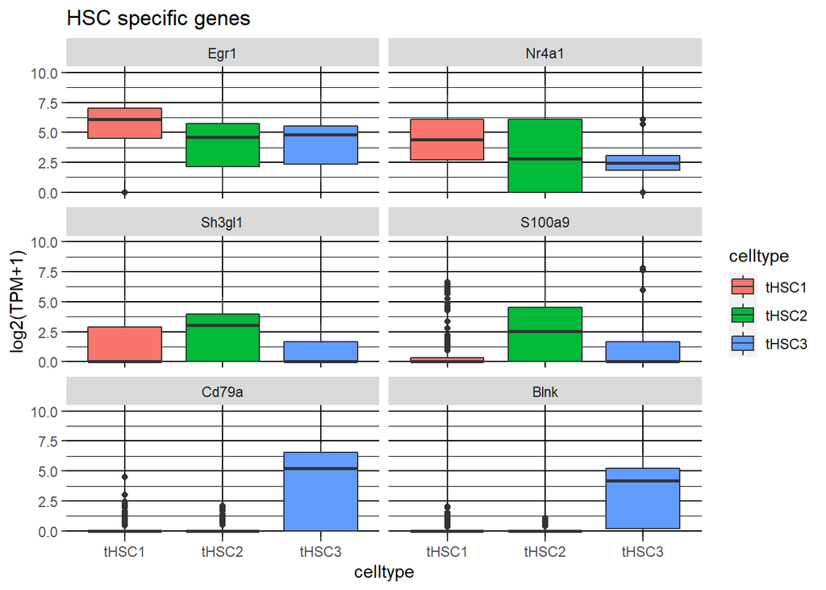

```r
colnames(mMat) <- c("celltype","gene","Expr")
mMat$celltype = factor(mMat$celltype,levels=c("tHSC1","tHSC2","tHSC3"))

ggplot(mMat,aes(x=celltype,y=Expr)) +
         geom_boxplot(aes(fill = celltype)) +
         xlab("celltype")+ ylab("log2(TPM+1)") +
         ggtitle("HSC specific genes") + coord_cartesian(ylim = c(0, 10)) +
  theme(panel.background = element_blank(),panel.grid=element_line(color="black",size=0.5)) +
  facet_wrap(~gene,ncol=2)
```

### Figure 1e

Histograms showing the compositions of each tHSC by five iHSC populations

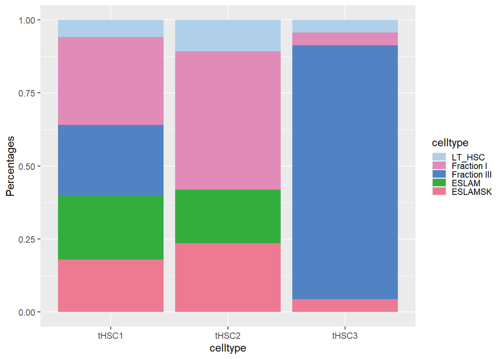

```r
library(corrplot)
library(ggplot2)
library(plyr)
### load data
load(paste0(pwd,"/input/05.Cluster.renumber.tMPPs.tsne.homeostasis_transplantation.RData"))


# calculate each phenotype cell percentages in predicted cell types
tsne.df.hsc <- tsne.df[tsne.df$predict_cell_type %in% c("tHSC1","tHSC2","tHSC3") & tsne.df$Time=="Ho",]
count.data <- ddply(tsne.df.hsc, .(predict_cell_type, phenotype), summarize, counts= length(phenotype))
percent.data <- ddply(count.data, .(predict_cell_type), summarise, phenotype=phenotype, counts=counts, percent=counts/sum(counts))
cell.order <- c("LT_HSC", "Fraction I", "Fraction III", "ESLAM", "ESLAMSK")
cell.order.predict <- c("tHSC1","tHSC2","tHSC3")
percent.data$phenotype <- factor(percent.data$phenotype,levels=cell.order,ordered=T)
percent.data$predict_cell_type <- factor(percent.data$predict_cell_type,levels=cell.order.predict,ordered=T)
percent.data <- percent.data[ order(percent.data$predict_cell_type, percent.data$phenotype), ]


ggplot(data=percent.data, aes(fill=phenotype)) +
     geom_bar(aes(x=predict_cell_type, y=percent), stat = "identity") +
     theme(legend.position="right") +
     scale_fill_manual(name="celltype",values=c("LT_HSC"="#AFD0E8","Fraction I"="#E08BB8","Fraction III"="#5183C4","ESLAM"="#33AE3E",
     "ESLAMSK"="#ED7A92",breaks=cell.order)) +
     guides(fill=guide_legend(keywidth=0.2,keyheight=0.1,default.unit="inch")) +
     xlab("celltype") + ylab("Percentages")
```

### Figure 1f

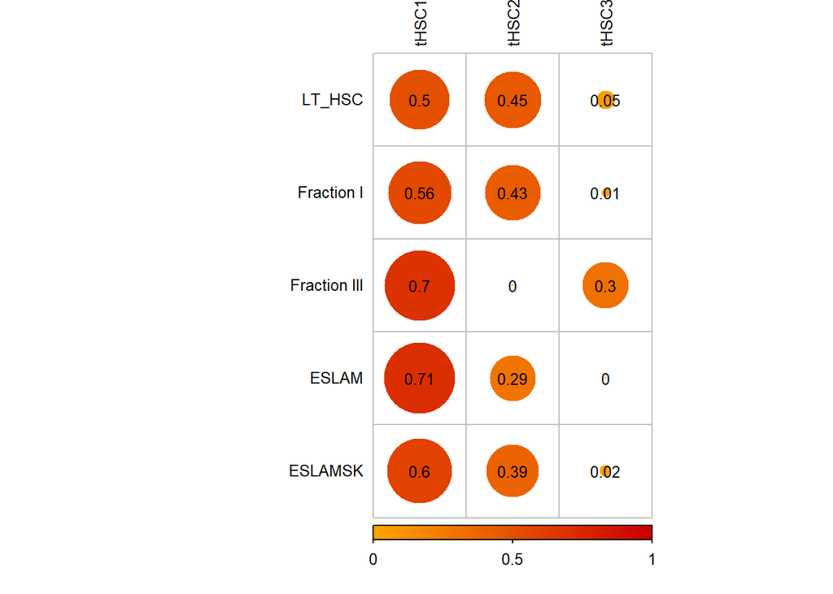

```r
# calculate each predicted cell type percentages in phenotype cells
count.data <- ddply(tsne.df.hsc, .(phenotype, predict_cell_type), summarize, counts= length(predict_cell_type))
percent.data <- ddply(count.data, .(phenotype), summarise, predict_cell_type=predict_cell_type, counts=counts, percent=counts/sum(counts))
percent.data$phenotype <- factor(percent.data$phenotype,levels=cell.order,ordered=T)
percent.data$predict_cell_type <- factor(percent.data$predict_cell_type,levels=cell.order.predict,ordered=T)
percent.data <- percent.data[ order(percent.data$predict_cell_type, percent.data$phenotype), ]


Cellfreq <- data.frame("phenotype" = NULL, "predict_cell_type" = NULL, "counts"= NULL,"percent"= NULL,stringsAsFactors = F)
for(i in cell.order.predict){
     thisfreq <- data.frame("phenotype" = cell.order,"predict_cell_type" = i,"counts" = 0, "percent" = 0)
     filter <- percent.data[percent.data$predict_cell_type==i,]
     thisfreq <- rbind(filter,thisfreq)
     thisfreq <- thisfreq[!duplicated(thisfreq$phenotype),]
     thisfreq$phenotype <- factor(thisfreq$phenotype,levels=cell.order,ordered=T)
     thisfreq <- thisfreq[order(thisfreq$phenotype),]
     Cellfreq <- rbind(Cellfreq,thisfreq)
     }


## convert percentage value into a numeric matrix
Mat <- matrix(NA,nrow=length(cell.order),ncol=length(cell.order.predict))
rownames(Mat) <- cell.order
colnames(Mat) <- cell.order.predict
for(i in 1:length(cell.order.predict)){
     j <- cell.order.predict[i]
     Mat[,j] <- Cellfreq[Cellfreq$predict_cell_type==j,"percent"]
     }
dat <- apply(Mat,2,as.numeric)
rownames(dat) <- rownames(Mat)
# plot
col <- colorRampPalette(c( 'white','orange','red3'))
corrplot(dat, is.corr = FALSE,tl.cex = 0.8,addCoef.col = "black",
     addrect = 2,
     rect.col = "white",
     method="circle",
     cl.lim=c(0,1),
     cl.length=3,
     addCoefasPercent = FALSE,
     col=col(100),
     cl.pos="b",
     cl.cex = 0.8,
     cl.ratio = 0.15,
     number.cex=0.8,
     number.font=1,
     tl.col="black")
```